# Bike Share Analysis

Damola Mabogunje

9/22/2021

## Introduction

This is my data analysis for the Cyclistic bike-share analysis case study. In this R project, you will find the steps I took to answer the key business question, posed by the Case Study. I have followed the steps of the data analysis process: Ask, Prepare, Process, Analyze, Share, and Act. Along the way, I determine the answers to the Business tasks put before me.

By the end of this file, I will have presented a portfolio-ready case study that answers the question:

> In what ways do members and casual riders use Cyclistic bikes differently?

## Setup

First, I need to import the following libraries for use in my analysis:

- tidyr - Helps with Data Import & Wrangling
- dplyr - Helps with Data Wrangling
- here - Simplifies File Referencing
- lubridate - For working with Dates
- geosphere - To calculate Geographic Distances from longitudes & latitudes
- ggplot2 - For Visualizing Data

## Verifying the Data

Data for this Analysis was secured from an online bucket / datasource of the last several months of a Bike Sharing Company’s bike trips. This resource was provided by a 2nd party source i.e Google, for the purpose of analysis. They in turn got it from Motivate Inc who operate the Divvy Bike Share Service for the City of Chicago.

I verified this information by visiting the respective websites, and ascertaining that Divvy indeed exists, and is providing their data under a license. I reviewed the license and found everything to be in order. So in fact, the data did “ROCCC.” That is, it was Reliable, Original, Current (I used data from the last 12 months), Cited, and Comprehensive.

## Exploring the Data

To get a sense of the data, I picked the most recent file in my dataset, and browsed it with a couple of R Commands from the Tidyverse and Dplyr

```r
aug_2021_biketrips <- read.csv(here("data/202108-divvy-tripdata.csv"))
head(aug_2021_biketrips)
```

```
##            ride_id rideable_type          started_at            ended_at
## 1 99103BB87CC6C1BB electric_bike 2021-08-10 17:15:49 2021-08-10 17:22:44
## 2 EAFCCCFB0A3FC5A1 electric_bike 2021-08-10 17:23:14 2021-08-10 17:39:24
## 3 9EF4F46C57AD234D electric_bike 2021-08-21 02:34:23 2021-08-21 02:50:36
## 4 5834D3208BFAF1DA electric_bike 2021-08-21 06:52:55 2021-08-21 07:08:13
## 5 CD825CB87ED1D096 electric_bike 2021-08-19 11:55:29 2021-08-19 12:04:11
## 6 612F12C94A964F3E electric_bike 2021-08-19 12:41:12 2021-08-19 12:47:47
##   start_station_name start_station_id end_station_name end_station_id start_lat
## 1                                                                         41.77
## 2                                                                         41.77
## 3                                                                         41.95
## 4                                                                         41.97
## 5                                                                         41.79
## 6                                                                         41.81
##   start_lng end_lat end_lng member_casual
## 1    -87.68   41.77  -87.68        member
## 2    -87.68   41.77  -87.63        member
## 3    -87.65   41.97  -87.66        member
## 4    -87.67   41.95  -87.65        member
## 5    -87.60   41.77  -87.62        member
## 6    -87.61   41.80  -87.60        member
```

```r
glimpse(aug_2021_biketrips)
```

```
## Rows: 804,352
## Columns: 13
## $ ride_id            <chr> "99103BB87CC6C1BB", "EAFCCCFB0A3FC5A1", "9EF4F46C57…
## $ rideable_type      <chr> "electric_bike", "electric_bike", "electric_bike", …
## $ started_at         <chr> "2021-08-10 17:15:49", "2021-08-10 17:23:14", "2021…
## $ ended_at           <chr> "2021-08-10 17:22:44", "2021-08-10 17:39:24", "2021…
## $ start_station_name <chr> "", "", "", "", "", "", "", "", "", "", "", "", "",…
## $ start_station_id   <chr> "", "", "", "", "", "", "", "", "", "", "", "", "",…
## $ end_station_name   <chr> "", "", "", "", "", "", "", "Clark St & Grace St", …
## $ end_station_id     <chr> "", "", "", "", "", "", "", "TA1307000127", "", "",…
## $ start_lat          <dbl> 41.77000, 41.77000, 41.95000, 41.97000, 41.79000, 4…
## $ start_lng          <dbl> -87.68000, -87.68000, -87.65000, -87.67000, -87.600…
## $ end_lat            <dbl> 41.77000, 41.77000, 41.97000, 41.95000, 41.77000, 4…
## $ end_lng            <dbl> -87.68000, -87.63000, -87.66000, -87.65000, -87.620…
## $ member_casual      <chr> "member", "member", "member", "member", "member", "…
```

Now, having looked at the first few rows, I notice that the dates for **started_at** and **ended_at** are stored as characters instead of datetimes, so I want to change that using the *lubridate* library. I also notice that the latitude and longitude of the startpoint and endpoint are recorded. With these, I should be able to calculate the distance travelled using the *geosphere* library.

```r
aug_2021_biketrips <- aug_2021_biketrips %>%
  mutate(started_at = ymd_hms(started_at)) %>%
  mutate(ended_at = ymd_hms(ended_at)) %>%
  mutate(distance = distHaversine(cbind(start_lng, start_lat), cbind(end_lng, end_lat)))
```

With that done, we can now add a calculated column of the ride length on each ride. I have a theory that the people who spend the most time cycling, are either members or casual cyclists more likely to become members.

```r
aug_2021_biketrips <- aug_2021_biketrips %>%
  mutate(ride_length = ended_at - started_at) %>%
  mutate(time_spent = seconds_to_period(ride_length)) %>%
  mutate(day_of_week = weekdays(started_at)) %>%
  arrange(-ride_length)

head(aug_2021_biketrips)
```

```
##            ride_id rideable_type          started_at            ended_at
## 1 E25E58F5E94EE351   docked_bike 2021-08-01 18:53:10 2021-08-30 16:42:20
## 2 1C60DEC1340B634D   docked_bike 2021-08-11 00:58:55 2021-08-23 13:30:12
## 3 DF061792D01293BE   docked_bike 2021-08-06 16:05:46 2021-08-17 07:01:28
## 4 EF79D8C828ABA5AA   docked_bike 2021-08-01 17:42:09 2021-08-11 03:09:10
## 5 D328EEB2F3BC4403   docked_bike 2021-08-08 14:42:14 2021-08-17 17:23:57
## 6 FFB9FA873E16CA6D   docked_bike 2021-08-14 23:28:41 2021-08-23 21:10:12
##                start_station_name start_station_id
## 1     Michigan Ave & Jackson Blvd     TA1309000002
## 2      Kedzie Ave & Milwaukee Ave            13085
## 3           Indiana Ave & 31st St     TA1308000036
## 4 Lakefront Trail & Bryn Mawr Ave     KA1504000152
## 5                  Shedd Aquarium            15544
## 6        Glenwood Ave & Morse Ave     KA1504000175
##                  end_station_name                      end_station_id start_lat
```

[output cut: 20 more lines]

Wow! Contrary to my expectation, casual cyclists topped the list of time spent biking. Let me see if that holds true across the board.

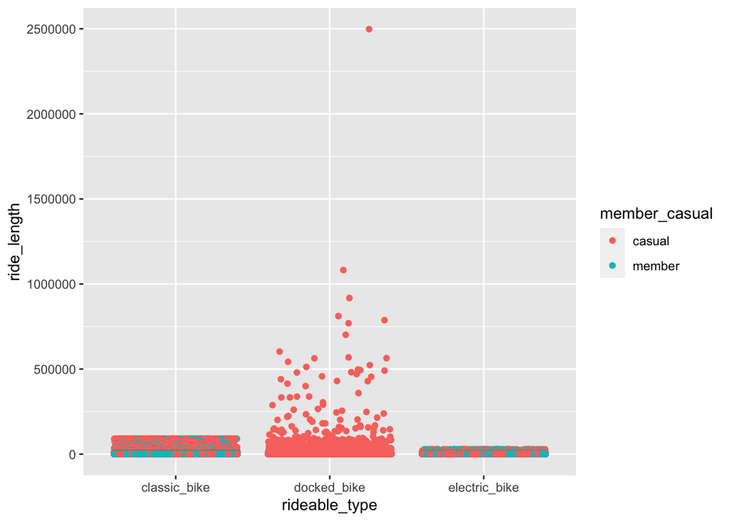

```r
ggplot(aug_2021_biketrips) +
  geom_jitter(aes(x = rideable_type, y = ride_length, color = member_casual))
```

Yes it does. Not only do casual riders spend more time cycling, but they also seem to have a preference for the docked bike (over electric, and classic). But, this was simply the case in August 2021. Let’s look back over the course of 12 months and see if the data still reflects the same way.

## Creating The Full Dataset

```r
biketrips <- list.files(path = here("data"), full.names = TRUE) %>%
  lapply(read.csv) # %>%
# bind_rows

# Bind rows doesn't work because for some reason the start_station_id and end_station_id column doesn't maintain the same data type across files. So we're just going to have to fix it up..

merged_biketrips <- bind_rows(biketrips[1], biketrips[2], biketrips[3])

merged_biketrips <- merged_biketrips %>%
  mutate(start_station_id = as.character(start_station_id)) %>%
  mutate(end_station_id = as.character(end_station_id))

merged_biketrips_2 <- bind_rows(biketrips[4], biketrips[5], biketrips[6],
                                biketrips[7], biketrips[8], biketrips[9],
                                biketrips[10], biketrips[11], biketrips[12])

merged_biketrips <- bind_rows(merged_biketrips, merged_biketrips_2)
```

Now we have all the data, we can see if the august sample was reflective of the whole population. But first we need to rebuild the calculated columns in our full dataset.

```r
all_trips <- merged_biketrips %>%
  mutate(started_at = ymd_hms(started_at)) %>%
  mutate(ended_at = ymd_hms(ended_at)) %>%
  mutate(ride_length = ended_at - started_at) %>%
  mutate(day_of_week = weekdays(started_at)) %>%
  mutate(distance = distHaversine(cbind(start_lng, start_lat), cbind(end_lng, end_lat)))

head(all_trips)
```

```
##            ride_id rideable_type          started_at            ended_at
## 1 2B22BD5F95FB2629 electric_bike 2020-09-17 14:27:11 2020-09-17 14:44:24
## 2 A7FB70B4AFC6CAF2 electric_bike 2020-09-17 15:07:31 2020-09-17 15:07:45
## 3 86057FA01BAC778E electric_bike 2020-09-17 15:09:04 2020-09-17 15:09:35
## 4 57F6DC9A153DB98C electric_bike 2020-09-17 18:10:46 2020-09-17 18:35:49
## 5 B9C4712F78C1AE68 electric_bike 2020-09-17 15:16:13 2020-09-17 15:52:55
## 6 378BBCE1E444EB80 electric_bike 2020-09-17 18:37:04 2020-09-17 19:23:28
##               start_station_name start_station_id           end_station_name
## 1         Michigan Ave & Lake St               52     Green St & Randolph St
## 2     W Oakdale Ave & N Broadway             <NA> W Oakdale Ave & N Broadway
## 3     W Oakdale Ave & N Broadway             <NA> W Oakdale Ave & N Broadway
## 4 Ashland Ave & Belle Plaine Ave              246            Montrose Harbor
## 5       Fairbanks Ct & Grand Ave               24   Fairbanks Ct & Grand Ave
## 6        Clark St & Armitage Ave               94
##   end_station_id start_lat start_lng  end_lat   end_lng member_casual
## 1            112  41.88669 -87.62356 41.88357 -87.64873        casual
## 2           <NA>  41.94000 -87.64000 41.94000 -87.64000        casual
## 3           <NA>  41.94000 -87.64000 41.94000 -87.64000        casual
## 4            249  41.95606 -87.66892 41.96398 -87.63822        casual
## 5             24  41.89186 -87.62101 41.89135 -87.62032        casual
## 6           <NA>  41.91826 -87.63636 41.88000 -87.62000        casual
##   ride_length day_of_week   distance
## 1   1033 secs    Thursday 2114.79885
## 2     14 secs    Thursday    0.00000
## 3     31 secs    Thursday    0.00000
## 4   1503 secs    Thursday 2690.04770
## 5   2202 secs    Thursday   80.42546
## 6   2784 secs    Thursday 4470.14097
```

Finally, we can reconsider the plot of ride length by casual and member riders per bike type.

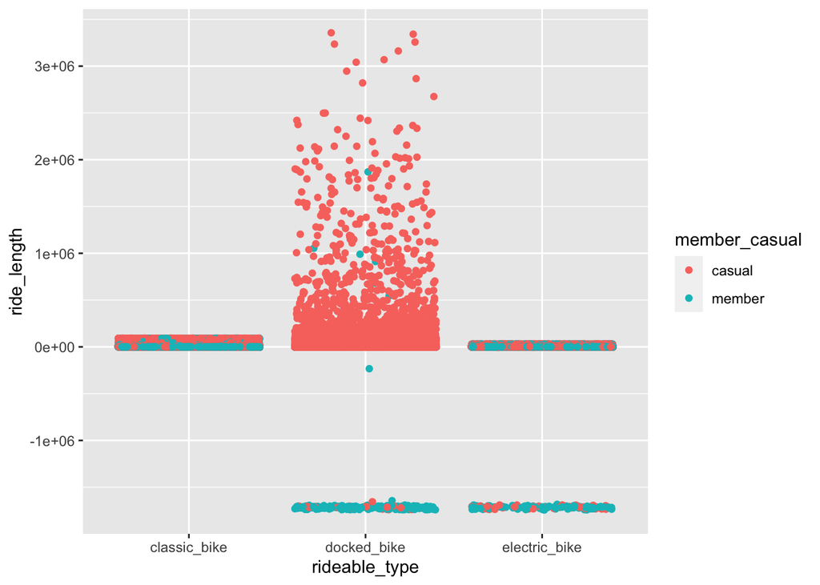

```r
ggplot(all_trips) +
  geom_jitter(aes(x = rideable_type, y = ride_length, color = member_casual))
```

As shown on the plot above, there is some dirty data: rides with negative ride lengths for starters. So we need to clean our data. Lets start by keeping only rides with positive distances or ride lengths. So at least we know that they are valid trips.

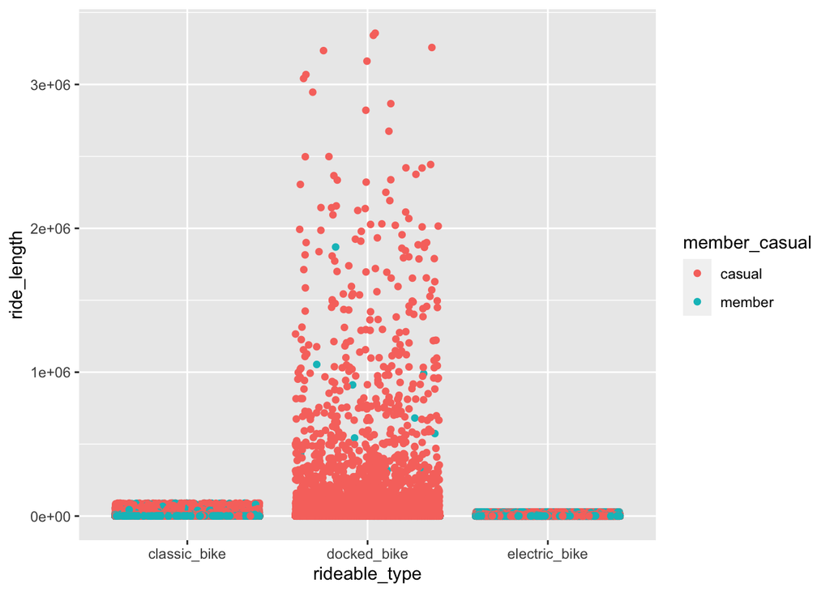

```r
# Keep the fields we want for bike trips that have valid ride length & distance
all_trips <- all_trips %>%
  select(ride_id,
         rideable_type,
         started_at,
         ended_at,
         distance,
         member_casual,
         ride_length,
         day_of_week) %>%
  filter(distance > 0) %>% # Only bikes
  filter(ride_length > 0)  # that have been used

# Plot the cleaned dataset to crosscheck

ggplot(all_trips) +
  geom_jitter(aes(x = rideable_type, y = ride_length, color = member_casual))
```

Let’s also check out what the most popular day for riding was by the different member types.

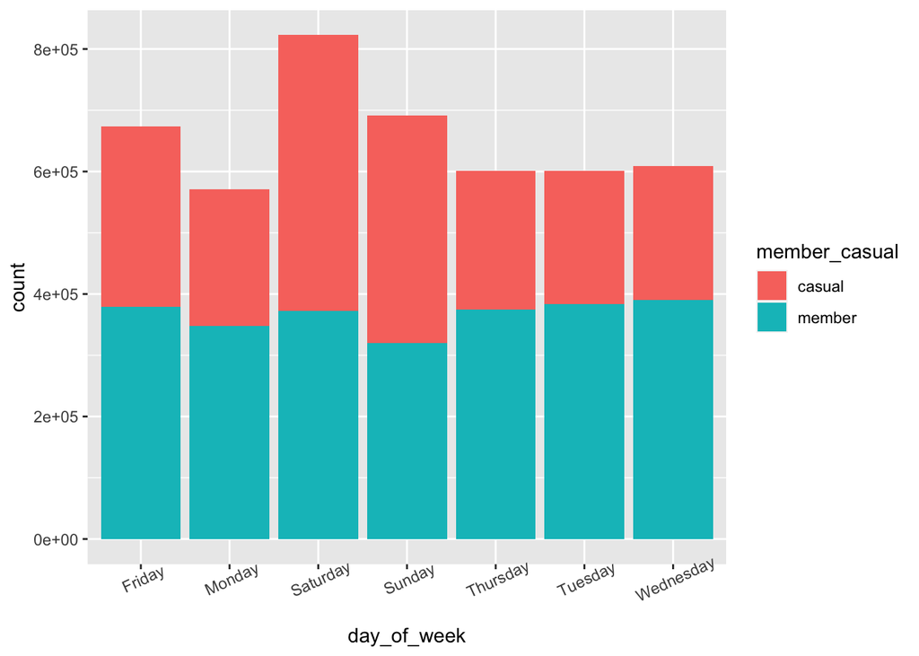

```r
ggplot(all_trips) +
  geom_bar(aes(x = day_of_week, fill = member_casual)) +
  theme(axis.text.x = element_text(angle = 25))
```

And then lets check out the relationship between bikes and travel distances by member type

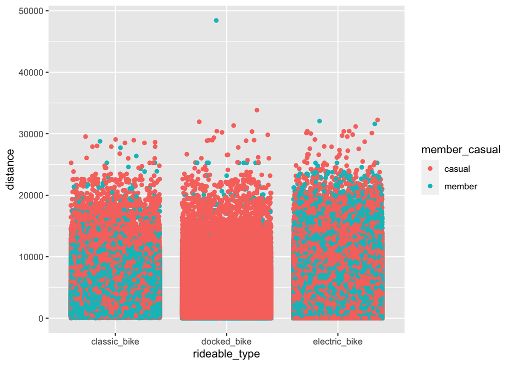

```r
ggplot(all_trips) +
  geom_jitter(aes(x = rideable_type, y = distance, color = member_casual))
```

## Conclusions

So, given this information, what are my top 3 recommendations?

1. Perhaps create a special offer for members using docked bikes. To encourage docked bike users (mostly casual) to consider taking up memberships.
2. Perhaps offer discounts on the weekends for members. Again to encourage weekend riders (mostly casual), to become members.
3. Finally, a public leaderboard might be an interesting idea. To recognize riders who spend the most time biking (currently casual riders), and encourage people to ride more.